# **Flow-Based Network Intrusion Detection (Binary Classification)**

#### Author: Luis Rito Filipe

#### June, 2023

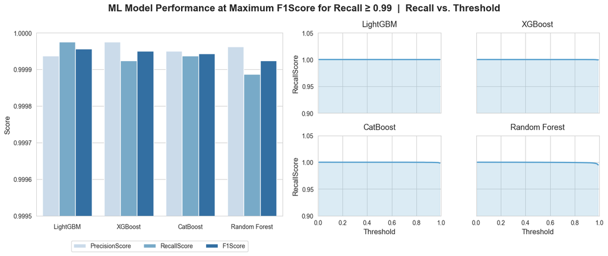

# Summary

The following study evaluates multiple machine learning models for network intrusion detection, formulated as a binary classification problem, with the objective of maximizing malicious traffic detection while minimizing false positives.

Among the evaluated models, LightGBM was selected as the final model, as it consistently achieved high performance across all evaluation metrics and satisfied the defined constraint (Recall ≥ 0.99). While differences between the top-performing models are minimal, LightGBM provides a favorable balance between recall and precision under threshold tuning, aligning with the objective of maximizing malicious traffic detection while maintaining acceptable false positive rates.

The results further indicate that malicious traffic detection is largely driven by a limited subset of flow-based features, with highlight to features "Subflow Fwd Bytes", "Packet Length Std" and "Init_Win_bytes_forward". Despite variations in feature importance across models, all approaches achieve near-perfect classification performance, suggesting that the dataset exhibits strong intrinsic separability in the selected feature space.

Due to the exceptionally high performance results and the irregular shape observed in the calibration curves, particularly the strong concentration of predicted probabilities near 0 and 1, an in-depth inspection for potential data leakage was conducted. This analysis revealed the presence of approximately 160,000 duplicated rows in the dataset. These duplicates correspond to repeated network traffic flows with identical feature values, a consequence of using exclusively flow-based features. However, a subsequent experiment in which duplicated rows were removed did not lead to any meaningful change in the final results.

To further investigate whether the performance was driven by model overfitting, the capacity of the best-performing algorithm (LightGBM) was reduced. This was achieved by constraining the tree complexity, yet the results remained effectively unchanged, suggesting that model capacity or tuning was not the primary factor behind the observed performance.

Additionally, data splitting was carefully inspected to rule out overlapping samples between training and test sets, with no evidence of leakage found.

# About The Study

The objective of the following study is to compare machine learning algorithms when applied to data analysis to detect malicious traffic. To achieve this, I will leverage widely used Python libraries specialized in data analysis and machine learning, including tools for data manipulation, visualization, and predictive modeling. The study will progress from exploratory data analysis to more advanced techniques, such as feature engineering and fraud detection modeling, to provide meaningful insights into the characteristics of malicious traffic detection.

# About The Dataset

The following study uses a dataset of network traffic publicly available from Kaggle (see link below). The dataset was produced by Canadian Institute for Cybersecurity.

Dataset link: https://www.kaggle.com/datasets/chethuhn/network-intrusion-dataset

```python
import gc
import pandas as pd
import numpy as np
#import time
#import threading
#import csv, sqlite3
#import statistics
import matplotlib.pyplot as plt
import matplotlib.colors as mcolors
from matplotlib.colors import LinearSegmentedColormap, TwoSlopeNorm, Normalize
import matplotlib.gridspec as gridspec
#import plotly.graph_objects as go
from plotly.subplots import make_subplots
import seaborn as sns
#from datetime import date, timedelta
# from ibapi.client  import EClient
# from ibapi.wrapper import EWrapper
# from ibapi.contract import Contract
# from ibapi.ticktype import TickTypeEnum
from sklearn.preprocessing import StandardScaler
from sklearn.feature_selection import f_classif, mutual_info_classif
from sklearn.model_selection import train_test_split
from sklearn.linear_model import LogisticRegression
from sklearn.metrics import confusion_matrix, precision_score, recall_score, f1_score, precision_recall_curve, roc_auc_score, roc_curve, average_precision_score, matthews_corrcoef, log_loss, brier_score_loss
from sklearn.calibration import calibration_curve
from sklearn.model_selection import RandomizedSearchCV, StratifiedKFold
# from sklearn.svm import SVC
# from sklearn.tree import DecisionTreeClassifier
# from sklearn.neighbors import KNeighborsClassifier
from sklearn.ensemble import RandomForestClassifier
from catboost import CatBoostClassifier
# from sklearn.neural_network import MLPClassifier
# from sklearn import metrics
from xgboost import XGBClassifier
from lightgbm import LGBMClassifier
import shap
import warnings

pd.set_option('display.max_rows', None)
pd.set_option('display.max_columns', None)
pd.set_option('display.max_colwidth', None)
warnings.filterwarnings("ignore")

def plot_confusion_matrix(y, y_predict):
    cm = confusion_matrix(y, y_predict)
    plt.figure(figsize=(4, 3))
    ax = sns.heatmap(cm, annot=True, fmt="d", cmap="Blues")
    ax.set_xlabel('Predicted labels', fontsize=11, labelpad=10)
    ax.set_ylabel('True labels', fontsize=11, labelpad=10)
    ax.set_title('Confusion Matrix', fontsize=13, pad=14, fontweight="bold")
    ax.xaxis.set_ticklabels(['Is not attack', 'Is attack'])
    ax.yaxis.set_ticklabels(['Is not attack', 'Is attack'])
    plt.tight_layout()
    plt.show()
```

# Methodology

- Data Wrangling and Preprocessing
- Exploratory Data Analysis and Feature Evaluation
- Model Training
- Model Comparison and Selection
- Final Evaluation and Conclusion

# Data Wrangling and Preprocessing

Two datasets with exact the same 79 features, one with DDoS attacks and other with PortScan-related traffic, were used. After loading and merging the datasets, data was prepared.

```python
df1 = pd.read_csv("Friday-WorkingHours-Afternoon-DDos.pcap_ISCX.csv")
df2 = pd.read_csv("Friday-WorkingHours-Afternoon-PortScan.pcap_ISCX.csv")
df = pd.concat([df1, df2], axis=0).reset_index(drop=True)
df.info(verbose=False)
df.describe()
```

```
<class 'pandas.core.frame.DataFrame'>
RangeIndex: 512212 entries, 0 to 512211
Columns: 79 entries,  Destination Port to  Label
dtypes: float64(24), int64(54), object(1)
memory usage: 308.7+ MB
```

|  | Destination Port | Flow Duration | Total Fwd Packets | Total Backward Packets | Total Length of Fwd Packets | Total Length of Bwd Packets | Fwd Packet Length Max | Fwd Packet Length Min | Fwd Packet Length Mean | Fwd Packet Length Std | Bwd Packet Length Max | Bwd Packet Length Min | Bwd Packet Length Mean | Bwd Packet Length Std | Flow Bytes/s | Flow Packets/s | Flow IAT Mean | Flow IAT Std | Flow IAT Max | Flow IAT Min | Fwd IAT Total | Fwd IAT Mean | Fwd IAT Std | Fwd IAT Max | Fwd IAT Min | Bwd IAT Total | Bwd IAT Mean | Bwd IAT Std | Bwd IAT Max | … |
| --- | --- | --- | --- | --- | --- | --- | --- | --- | --- | --- | --- | --- | --- | --- | --- | --- | --- | --- | --- | --- | --- | --- | --- | --- | --- | --- | --- | --- | --- | --- |
| count | 512212.000000 | 5.122120e+05 | 512212.000000 | 512212.000000 | 512212.000000 | 5.122120e+05 | 512212.000000 | 512212.000000 | 512212.000000 | 512212.000000 | 512212.000000 | 512212.000000 | 512212.000000 | 512212.000000 | 5.121930e+05 | 5.122120e+05 | 5.122120e+05 | 5.122120e+05 | 5.122120e+05 | 5.122120e+05 | 5.122120e+05 | 5.122120e+05 | 5.122120e+05 | 5.122120e+05 | 5.122120e+05 | 5.122120e+05 | 5.122120e+05 | 5.122120e+05 | 5.122120e+05 | … |
| mean | 8412.769090 | 1.016663e+07 | 4.091019 | 3.984264 | 544.584561 | 4.141029e+03 | 282.666408 | 18.078026 | 86.143519 | 108.468259 | 1309.471908 | 22.736429 | 435.251879 | 573.344087 | inf | inf | 8.887531e+05 | 2.246625e+06 | 6.963890e+06 | 1.883560e+04 | 9.724758e+06 | 1.555440e+06 | 2.574144e+06 | 6.718783e+06 | 3.421505e+05 | 5.671966e+06 | 8.635275e+05 | 9.312839e+05 | 2.890904e+06 | … |
| std | 17447.963843 | 2.712714e+07 | 17.841275 | 25.620921 | 2592.815800 | 4.619398e+04 | 1281.867186 | 110.274825 | 347.365649 | 544.842538 | 2800.858963 | 52.869257 | 860.129260 | 1298.281072 | NaN | NaN | 2.473728e+06 | 6.080575e+06 | 1.983521e+07 | 5.790381e+05 | 2.704408e+07 | 6.023558e+06 | 7.771771e+06 | 2.023747e+07 | 5.002368e+06 | 2.159339e+07 | 5.574226e+06 | 4.089487e+06 | 1.265023e+07 | … |
| min | 0.000000 | -1.300000e+01 | 1.000000 | 0.000000 | 0.000000 | 0.000000e+00 | 0.000000 | 0.000000 | 0.000000 | 0.000000 | 0.000000 | 0.000000 | 0.000000 | 0.000000 | -1.930000e+08 | -2.000000e+06 | -1.300000e+01 | 0.000000e+00 | -1.300000e+01 | -1.300000e+01 | 0.000000e+00 | 0.000000e+00 | 0.000000e+00 | 0.000000e+00 | -1.200000e+01 | 0.000000e+00 | 0.000000e+00 | 0.000000e+00 | 0.000000e+00 | … |
| 25% | 80.000000 | 5.500000e+01 | 1.000000 | 1.000000 | 2.000000 | 6.000000e+00 | 2.000000 | 0.000000 | 2.000000 | 0.000000 | 6.000000 | 0.000000 | 6.000000 | 0.000000 | 1.568228e+02 | 3.160119e+00 | 5.333333e+01 | 0.000000e+00 | 5.500000e+01 | 3.000000e+00 | 0.000000e+00 | 0.000000e+00 | 0.000000e+00 | 0.000000e+00 | 0.000000e+00 | 0.000000e+00 | 0.000000e+00 | 0.000000e+00 | 0.000000e+00 | … |
| 50% | 146.000000 | 3.027600e+04 | 2.000000 | 1.000000 | 26.000000 | 6.000000e+00 | 6.000000 | 2.000000 | 6.000000 | 0.000000 | 6.000000 | 6.000000 | 6.000000 | 0.000000 | 2.634817e+04 | 1.656658e+02 | 7.943167e+03 | 1.154744e+02 | 2.456900e+04 | 2.200000e+01 | 3.000000e+00 | 3.000000e+00 | 0.000000e+00 | 3.000000e+00 | 1.000000e+00 | 0.000000e+00 | 0.000000e+00 | 0.000000e+00 | 0.000000e+00 | … |
| 75% | 5544.000000 | 2.033681e+06 | 4.000000 | 4.000000 | 62.000000 | 3.500000e+02 | 36.000000 | 6.000000 | 33.000000 | 6.094494 | 191.250000 | 6.000000 | 159.000000 | 9.899495 | 1.666667e+05 | 3.636364e+04 | 3.703694e+05 | 8.667981e+05 | 1.989960e+06 | 5.600000e+01 | 2.799100e+05 | 6.571646e+04 | 3.254759e+04 | 1.933665e+05 | 4.600000e+01 | 1.108765e+05 | 2.356893e+04 | 2.751521e+04 | 8.520375e+04 | … |
| max | 65532.000000 | 1.199999e+08 | 3119.000000 | 3635.000000 | 232349.000000 | 7.150819e+06 | 13929.000000 | 1472.000000 | 3867.000000 | 6692.644993 | 11680.000000 | 1460.000000 | 5800.500000 | 8194.660487 | inf | inf | 1.070000e+08 | 8.480000e+07 | 1.200000e+08 | 1.070000e+08 | 1.200000e+08 | 1.200000e+08 | 8.120000e+07 | 1.200000e+08 | 1.200000e+08 | 1.200000e+08 | 1.200000e+08 | 8.130000e+07 | 1.200000e+08 | … |

In this study only a subset from the 79 initial features was used (Flow Bytes/s, Flow Packets/s, Fwd Packets/s, Bwd Packets/s, Subflow Fwd Packets, Subflow Fwd Bytes, Packet Length Std, Packet Length Variance, Flow Duration, Init_Win_bytes_forward, Init_Win_bytes_backward, Down/Up Ratio, Label).

There are 10 features with only one unique value, which imply they have zero variance and cannot help distinguishing Label 0 vs Label 1. Mathematically, for models like logistic regression, the coefficient becomes meaningless and it may even cause numerical instability in some cases. If any of these were included in the subset used, it would also be removed.

Label feature contains three unique values. "BENIGN" will be replaced by 0 (normal), and "DDoS" and "PortScan" by 1 (malicious traffic). Label feature was renamed to Class. A space before or after each feature name was removed. A few rows with infinite values were removed. Rows with values of -1 in features "Init_Win_bytes_forward" and "Init_Win_bytes_backward" were removed as this is an indication that the information was not available or not applicable for a particular flow.

```python
df.columns = df.columns.str.strip()
df = df[['Flow Bytes/s', 'Flow Packets/s', 'Fwd Packets/s', 'Bwd Packets/s', 'Subflow Fwd Packets', 'Subflow Fwd Bytes', 'Packet Length Std', 'Packet Length Variance', 'Flow Duration', 'Init_Win_bytes_forward', 'Init_Win_bytes_backward', 'Down/Up Ratio', 'Label']]
remove_list = []
for i in range(len(df.columns)):
    if (len(df[df.columns[i]].unique()) == 1):
        remove_list.append(df.columns[i])
df["Label"] = df["Label"].isin(["DDoS", "PortScan"]).astype(int)
df = df.rename(columns={"Label": "Class"})
df.replace([np.inf, -np.inf], np.nan, inplace=True)
df = df.dropna().reset_index(drop=True)
df = df[(df["Init_Win_bytes_forward"] != -1) & (df["Init_Win_bytes_backward"] != -1)]
del df1, df2
gc.collect()
```

# Exploratory Data Analysis and Feature Evaluation

Feature correlation analysis helped identify strongly correlated feature pairs, allowing for the removal of redundant variables and improving model robustness. Below, the summary statistics of the dataset reduced and prepared for the machine learning algorithms. The dataset shows moderate class imbalance (69.3% malicious traffic).

```python
def feature_correlation_check(data, threshold=0.95):
    X = data.drop("Class", axis=1)
    y = data["Class"]
    scaler = StandardScaler()
    X = pd.DataFrame( scaler.fit_transform(X), columns=X.columns, index=X.index )
    corr_matrix_before = X.corr().abs()
    upper = corr_matrix_before.where( np.triu(np.ones(corr_matrix_before.shape), k=1).astype(bool) )
    pairs = upper.stack().reset_index()
    pairs.columns = ["feature_1", "feature_2", "correlation"]
    redundant_pairs = pairs[pairs["correlation"] > threshold].sort_values("correlation", ascending=False)
    mi = mutual_info_classif(X, y)
    mi_lookup = pd.Series(mi, index=X.columns).to_dict()
    to_remove = set()

    for _, row in redundant_pairs.iterrows():
        f1, f2 = row["feature_1"], row["feature_2"]
        mi1 = mi_lookup.get(f1, 0)
        mi2 = mi_lookup.get(f2, 0)
        if mi1 < mi2:
            to_remove.add(f1)
        else:
            to_remove.add(f2)

    corr_matrix_after = X.drop(list(to_remove), axis=1).corr().abs()
    mi = pd.DataFrame({"Feature": X.columns, "MI": mi}).sort_values("MI", ascending=False).reset_index(drop=True).T

    return redundant_pairs, to_remove, corr_matrix_before, corr_matrix_after, mi

redundant_pairs, to_drop, corr_matrix_before, corr_matrix_after, mi = feature_correlation_check(df)
df = df.drop(to_drop, axis=1)
```

The following chart illustrates the correlation between the target variable Class and the independent features. The results indicate that no feature exhibits a strong correlation, positive or negative.

It is important to note that correlation measures linear relationships only and does not capture potential nonlinear interactions between variables. Therefore, features with low correlation may still contribute to model performance when combined with other variables or when nonlinear effects are considered.

[figure not shown]

```python
def plot_feature_correlation():
    corr = df.corr()["Class"].drop("Class").sort_values(ascending=False)
    sns.set_style("whitegrid")

    values = corr.values
    colors = [sns.color_palette("Blues", n_colors=5)[3] if val >= 0 else sns.color_palette("Reds", n_colors=5)[3] for val in values]

    fig, ax = plt.subplots(figsize=(13, 3.2))

    sns.barplot(
        x=corr.index,
        y=corr.values,
        hue=corr.index,
        palette=colors,
        edgecolor="white",
        legend=False,
        ax=ax
    )

    ax.tick_params(axis='x', rotation=45)
    ax.set_title("Correlation with Class", fontsize=13, fontweight="bold", pad=14)
    ax.set_xlabel(None)
    ax.set_ylabel("Correlation")
    ax.axhline(y=0, color="black", linewidth=0.3)

    fig.canvas.draw()
    renderer = fig.canvas.get_renderer()
    max_height_px = max(
        label.get_window_extent(renderer=renderer).height
        for label in ax.get_xticklabels()
    )
    dpi = fig.dpi
    extra_height_inch = max_height_px / dpi
    fig.set_size_inches(12, 3 + extra_height_inch)

    plt.tight_layout()
    plt.show()

plot_feature_correlation()
```

Boxplot analysis highlights that malicious traffic (Class 1) generally exhibits fewer outliers across most features, indicating more regular and constrained behavior compared to normal traffic, particularly in features such as “Subflow Fwd Bytes” and “Subflow Fwd Packets”. This supports the idea that normal traffic, associated with browsing, streaming, downloads, and API interactions, is more diverse, whereas malicious traffic tends to be automated and repetitive in nature. However, feature "Flow Duration" shows notable outliers for malicious traffic, suggesting occasional extreme deviations, possibly corresponding to bursts of activity or sustained malicious traffic flows. Overall, malicious traffic patterns appear more structured but also revealing sporadic high-intensity events.

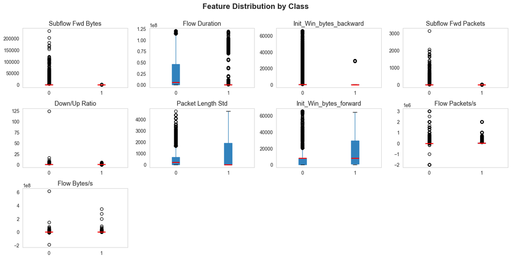

```python
def plot_box_subplots():
    corr = df.corr(numeric_only=True)["Class"].drop("Class").abs().sort_values(ascending=False)
    features = corr.index
    n_features = len(features)
    cols = 4
    rows = int(np.ceil(n_features / cols))
    fig, axes = plt.subplots(rows, cols, figsize=(15, rows * 2.5))

    axes = axes.flatten()
    df1 = df.copy()

    for i, col in enumerate(features):
        df1.boxplot(column=col, by="Class", ax=axes[i], grid=False, boxprops=dict(facecolor="#3182bd", color="#3182bd"), medianprops=dict(color="Red", linewidth=2), patch_artist=True)
        axes[i].set_title(col, fontsize=13)
        axes[i].set_xlabel("")

    for j in range(len(features), len(axes)):
        fig.delaxes(axes[j])

    plt.suptitle("Feature Distribution by Class", y=1.001, fontsize=16, fontweight="bold")
    plt.tight_layout()
    plt.show()

plot_box_subplots()
```

# Model Training

In the next step, the dataset is split into training and testing sets to allow proper training of the classification models and unbiased evaluation of their performance.

```python
models = dict()
X = df.drop("Class", axis=1)
Y = df["Class"]
X_train, X_test, Y_train, Y_test = train_test_split(X, Y, test_size=0.33, random_state=42, stratify=Y)

print('X_train.shape=', X_train.shape, 'Y_train.shape=', Y_train.shape)
print('X_test.shape=', X_test.shape, 'Y_test.shape=', Y_test.shape)

def inspection():
    for col in X.columns:
        auc = roc_auc_score(Y, X[col])
        if auc > 0.95 or auc < 0.05:
            print(col, auc)
    duplicates = X.duplicated().sum()
    train_hash = pd.util.hash_pandas_object(X_train).isin(
        pd.util.hash_pandas_object(X_test)
    ).sum()
    print("Duplicates:", duplicates, "Overlap rows:", train_hash)
```

```
X_train.shape= (232251, 9) Y_train.shape= (232251,)
X_test.shape= (114393, 9) Y_test.shape= (114393,)
```

The number of duplicated rows in the dataset exceeds 160,000 when using the current subset of features. When the full feature set is used, this number decreases to approximately 68,000, indicating that feature selection increases the level of redundancy in the representation of network traffic flows.

```python
duplicates = X.duplicated().sum()
print("Duplicates:", duplicates)
```

```
Duplicates: 161702
```

The folowing shows that there are no overlapping rows between train and test datasets.

```python
train_hash = pd.util.hash_pandas_object(X_train).isin(pd.util.hash_pandas_object(X_test)).sum()
print("Overlap rows:", train_hash)
```

```
Overlap rows: 0
```

## Logistic Regression

Logistic Regression is a supervised machine learning algorithm used for classification tasks, particularly binary classification problems where the target variable takes values such as 0/1, true/false, or yes/no. In this study, it is applied to predict the "Class" variable, which indicates whether network flows are associated with malicious traffic or not. Despite its simplicity, Logistic Regression can perform well in high-dimensional datasets and provide a strong baseline for comparison with more complex models. Given the large number of observations relative to the number of features in this dataset, the model is less likely to overfit, although regularization and class imbalance handling remain important considerations. The coefficients of the Logistic Regression model provide insight into the direction and relative importance of each feature. Positive values indicate an increase in the likelihood of a network flow being classified as malicious traffic, while negative values indicate the opposite. The magnitude of the coefficients reflects the strength of the relationship. Below is the implementation of Logistic Regression with hyperparameter tuning, with emphasis on the adjustment of class weights.

```python
def run_logistic_regression():
    scaler = StandardScaler()
    X_train_scaled = scaler.fit_transform(X_train)
    X_test_scaled = scaler.transform(X_test)

    parameters = {
            "solver": ['lbfgs'],
            "class_weight": ["balanced"],
            "C": [0.01, 0.1, 1],
            "max_iter": [1000]
        }

    lr = LogisticRegression()

    cv = RandomizedSearchCV(
        estimator=lr,
        param_distributions=parameters,
        scoring={"recall": "recall", "f1": "f1", "precision": "precision"},
        refit="f1",
        cv=10,
        verbose=1,
        random_state=42,
        n_jobs=-1
    )

    cv.fit(X_train_scaled, Y_train)
    best_model = cv.best_estimator_
    proba = best_model.predict_proba(X_test_scaled)[:, 1]

    results = []
    for t in np.linspace(0.0, 1.0, 101):
        y_pred = (proba >= t)
        cm = confusion_matrix(Y_test, y_pred)
        results.append({
            "Threshold": t,
            "PrecisionScore": precision_score(Y_test, y_pred, zero_division=0),
            "RecallScore": recall_score(Y_test, y_pred, zero_division=0),
            "F1Score": f1_score(Y_test, y_pred, zero_division=0),
            "TP": cm[1, 1],
            "TN": cm[0, 0],
            "FP": cm[0, 1],
            "FN": cm[1, 0],
            "MCC": matthews_corrcoef(Y_test, y_pred)
        })

    df_metrics = pd.DataFrame(results)
    df_metrics.to_csv("log_regression_metrics.csv", index=False)
    df_cv_results = pd.DataFrame(cv.cv_results_)
    df_cv_results.to_csv("log_regression_cv_results.csv", index=False)

    coefficients = best_model.coef_[0]
    feature_names = X.columns
    df_coef = pd.DataFrame({
        "Feature": feature_names,
        "Coefficient": coefficients
    })
    df_coef = df_coef.sort_values("Coefficient", ascending=False).round(3).reset_index(drop=True).transpose()

    return { "metrics": df_metrics, "best_params": cv.best_params_, "best_model": best_model, "coefficients": df_coef, "cv_results": df_cv_results, "y_pred": y_pred, "y_proba": proba }

log_regression = run_logistic_regression()
models.update({"Logistic Regression": log_regression})
```

```python
log_regression["metrics"].iloc[50:55]
```

|  | Threshold | PrecisionScore | RecallScore | F1Score | TP | TN | FP | FN | MCC |
| --- | --- | --- | --- | --- | --- | --- | --- | --- | --- |
| 50 | 0.50 | 0.935009 | 0.995182 | 0.964157 | 78897 | 29630 | 5484 | 382 | 0.879658 |
| 51 | 0.51 | 0.936061 | 0.995144 | 0.964698 | 78894 | 29725 | 5389 | 385 | 0.881529 |
| 52 | 0.52 | 0.936558 | 0.995093 | 0.964939 | 78890 | 29770 | 5344 | 389 | 0.882358 |
| 53 | 0.53 | 0.936656 | 0.995068 | 0.964979 | 78888 | 29779 | 5335 | 391 | 0.882497 |
| 54 | 0.54 | 0.937046 | 0.995068 | 0.965186 | 78888 | 29814 | 5300 | 391 | 0.883211 |

The following table shows the computed feature coefficients ordered from highest to lowest.

```python
log_regression["coefficients"]
```

|  | 0 | 1 | 2 | 3 | 4 | 5 | 6 | 7 | 8 |
| --- | --- | --- | --- | --- | --- | --- | --- | --- | --- |
| Feature | Packet Length Std | Flow Duration | Init_Win_bytes_forward | Flow Packets/s | Flow Bytes/s | Init_Win_bytes_backward | Down/Up Ratio | Subflow Fwd Bytes | Subflow Fwd Packets |
| Coefficient | 10.632 | 1.421 | 0.995 | 0.073 | -0.303 | -1.012 | -1.733 | -42.989 | -46.788 |

A confusion matrix is shown below for a minimum probability equal to the threshold corresponding to the maximum F1Score for a RecallScore equal or higher than 0.99.

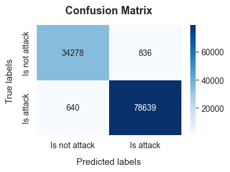

```python
plot_confusion_matrix(Y_test, log_regression["y_proba"] >= log_regression["metrics"][log_regression["metrics"]["RecallScore"] >= 0.99].sort_values("F1Score", ascending=False)["Threshold"].iloc[0])
```

## Random Forest

Random Forest is often expected to outperform Logistic Regression in network intrusion tasks, as it can capture nonlinear patterns, interactions between features, and is generally more robust regarding noise. The Random Forest hyperparameter search was optimized to reduce computational cost/time by limiting tree complexity and reducing cross-validation folds, while preserving model comparability across experiments.

```python
def run_random_forest():
    parameters = {
            "class_weight": ["balanced"],
            "n_estimators": [200],
            "max_depth": [5, 15],
            "min_samples_leaf": [5],
            "max_features": ["sqrt"]
        }

    rf = RandomForestClassifier( random_state=42, n_jobs=-1 )

    cv = RandomizedSearchCV(
        estimator=rf,
        param_distributions=parameters,
        n_iter=6,
        scoring={"recall": "recall", "f1": "f1", "precision": "precision"},
        refit="recall",
        cv=StratifiedKFold(n_splits=3, shuffle=True, random_state=42),
        verbose=1,
        random_state=42,
        n_jobs=-1
    )

    cv.fit(X_train, Y_train)

    best_model = cv.best_estimator_

    proba = best_model.predict_proba(X_test)[:, 1]

    results = []
    for t in np.linspace(0.0, 1.0, 101):
        y_pred = (proba >= t)
        cm = confusion_matrix(Y_test, y_pred)
        results.append({
            "Threshold": t,
            "PrecisionScore": precision_score(Y_test, y_pred, zero_division=0),
            "RecallScore": recall_score(Y_test, y_pred, zero_division=0),
            "F1Score": f1_score(Y_test, y_pred, zero_division=0),
            "TP": cm[1, 1],
            "TN": cm[0, 0],
            "FP": cm[0, 1],
            "FN": cm[1, 0],
            "MCC": matthews_corrcoef(Y_test, y_pred)
        })

    df_metrics = pd.DataFrame(results)
    df_metrics.to_csv("random_forest_metrics.csv", index=False)
    df_cv_results = pd.DataFrame(cv.cv_results_)
    df_cv_results.to_csv("random_forest_cv_results.csv", index=False)

    importances = best_model.feature_importances_
    df_importances = pd.DataFrame({
        "Feature": X.columns,
        "Importance": importances
    })
    df_importances = df_importances.sort_values("Importance", ascending=False).round(3).reset_index(drop=True).transpose()

    return { "metrics": df_metrics, "best_params": cv.best_params_, "best_model": best_model, "importances": df_importances, "cv_results": df_cv_results, "y_pred": y_pred, "y_proba": proba }

random_forest = run_random_forest()
models.update({"Random Forest": random_forest})
```

```python
random_forest["metrics"].iloc[50:55]
```

|  | Threshold | PrecisionScore | RecallScore | F1Score | TP | TN | FP | FN | MCC |
| --- | --- | --- | --- | --- | --- | --- | --- | --- | --- |
| 50 | 0.50 | 0.999962 | 0.999836 | 0.999899 | 79266 | 35111 | 3 | 13 | 0.999671 |
| 51 | 0.51 | 0.999962 | 0.999836 | 0.999899 | 79266 | 35111 | 3 | 13 | 0.999671 |
| 52 | 0.52 | 0.999975 | 0.999836 | 0.999905 | 79266 | 35112 | 2 | 13 | 0.999692 |
| 53 | 0.53 | 0.999987 | 0.999811 | 0.999899 | 79264 | 35113 | 1 | 15 | 0.999671 |
| 54 | 0.54 | 0.999987 | 0.999798 | 0.999893 | 79263 | 35113 | 1 | 16 | 0.999651 |

The following table shows the computed feature importance ordered from highest to lowest.

```python
random_forest["importances"]
```

|  | 0 | 1 | 2 | 3 | 4 | 5 | 6 | 7 | 8 |
| --- | --- | --- | --- | --- | --- | --- | --- | --- | --- |
| Feature | Subflow Fwd Bytes | Flow Bytes/s | Init_Win_bytes_backward | Packet Length Std | Init_Win_bytes_forward | Flow Packets/s | Flow Duration | Subflow Fwd Packets | Down/Up Ratio |
| Importance | 0.235 | 0.207 | 0.19 | 0.147 | 0.069 | 0.051 | 0.037 | 0.034 | 0.03 |

There is a noticeable difference in the importance attributed to features "Subflow Fwd Bytes" by each algorithm. "Subflow Fwd Bytes" measures how much forward data is transmitted within segments of a flow, providing insight into how traffic volume is distributed rather than just the total amount. A subflow is a segment of a larger flow. Malicious traffic flows (Class 1) tend to send less data forward per segment. This feature may reveal important patterns that can be captured by tree models such as Random Forest.

A confusion matrix is shown below for a minimum probability equal to the threshold corresponding to the maximum F1Score for a RecallScore equal or higher than 0.99.

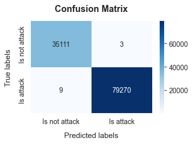

```python
plot_confusion_matrix(Y_test, random_forest["y_proba"] >= random_forest["metrics"][random_forest["metrics"]["RecallScore"] >= 0.99].sort_values("F1Score", ascending=False)["Threshold"].iloc[0])
```

## XGBoost

XGBoost is expected to show similar metrics compared to Random Forest in this task. Reducing the subsample and colsample_bytree (min ≥ 0.7) from default values (1.0) introduces randomness, reduces overfitting, improves generalization, forces feature diversity and reduces dominance of strong features. Shares some similarities with Random Forest. But while the later builds trees during training and outputs the average of the predictions from individual trees, XGBoost builds new trees sequentially and each new tree corrects errors from the previous tree, improving model's predictions.

```python
def run_xgboost():
    # Note: learning_rate -> estabilidade [0.02-0.05], max_depth -> complexidade [6-12], scale_pos_weight é o parâmetro mais importante para um recall elevado a probabilidades mais elevadas (thresholds)
    scale_pos_weight = len(Y_train[Y_train.eq(0)]) / len(Y_train[Y_train.eq(1)])

    parameters = {
        "n_estimators": [200, 300, 400],
        "max_depth": [0],
        "learning_rate": [0.01, 0.02, 0.05],
        "subsample": [0.7, 0.8, 0.9],
        "colsample_bytree": [0.7, 0.8, 0.9],
        "scale_pos_weight": [scale_pos_weight*0.5, scale_pos_weight, scale_pos_weight*1.5]
    }

    xgb = XGBClassifier( random_state=42, n_jobs=-1, eval_metric="logloss" )

    cv = RandomizedSearchCV(
        estimator=xgb,
        param_distributions=parameters,
        n_iter=20,
        scoring={"recall": "recall", "f1": "f1", "precision": "precision"},
        refit="recall",
        cv=StratifiedKFold(n_splits=3, shuffle=True, random_state=42),
        verbose=1,
        random_state=42,
        n_jobs=-1
    )

    cv.fit(X_train, Y_train)

    best_model = cv.best_estimator_

    proba = best_model.predict_proba(X_test)[:, 1]

    results = []
    for t in np.linspace(0.0, 1.0, 101):
        y_pred = (proba >= t)
        cm = confusion_matrix(Y_test, y_pred)
        results.append({
            "Threshold": t,
            "PrecisionScore": precision_score(Y_test, y_pred, zero_division=0),
            "RecallScore": recall_score(Y_test, y_pred, zero_division=0),
            "F1Score": f1_score(Y_test, y_pred, zero_division=0),
            "TP": cm[1, 1],
            "TN": cm[0, 0],
            "FP": cm[0, 1],
            "FN": cm[1, 0],
            "MCC": matthews_corrcoef(Y_test, y_pred)
        })

    df_metrics = pd.DataFrame(results)
    df_metrics.to_csv("xgboost_metrics.csv", index=False)
    df_cv_results = pd.DataFrame(cv.cv_results_)
    df_cv_results.to_csv("xgboost_cv_results.csv", index=False)

    importances = best_model.get_booster().get_score(importance_type="gain")
    df_importances = pd.DataFrame({
        "Feature": X.columns
    })
    df_importances["Importance"] = df_importances["Feature"].map(importances).fillna(0)
    df_importances = df_importances.sort_values("Importance", ascending=False).round().reset_index(drop=True).transpose()

    return { "metrics": df_metrics, "best_params": cv.best_params_, "best_model": best_model, "importances": df_importances, "cv_results": df_cv_results, "y_pred": y_pred, "y_proba": proba }

xgboost = run_xgboost()
models.update({"XGBoost": xgboost})
```

```python
xgboost["metrics"].iloc[50:55]
```

|  | Threshold | PrecisionScore | RecallScore | F1Score | TP | TN | FP | FN | MCC |
| --- | --- | --- | --- | --- | --- | --- | --- | --- | --- |
| 50 | 0.50 | 0.999924 | 0.999937 | 0.999931 | 79274 | 35108 | 6 | 5 | 0.999774 |
| 51 | 0.51 | 0.999924 | 0.999937 | 0.999931 | 79274 | 35108 | 6 | 5 | 0.999774 |
| 52 | 0.52 | 0.999924 | 0.999937 | 0.999931 | 79274 | 35108 | 6 | 5 | 0.999774 |
| 53 | 0.53 | 0.999924 | 0.999937 | 0.999931 | 79274 | 35108 | 6 | 5 | 0.999774 |
| 54 | 0.54 | 0.999924 | 0.999924 | 0.999924 | 79273 | 35108 | 6 | 6 | 0.999753 |

The following table shows the computed feature importance from highest to lowest.

```python
xgboost["importances"]
```

|  | 0 | 1 | 2 | 3 | 4 | 5 | 6 | 7 | 8 |
| --- | --- | --- | --- | --- | --- | --- | --- | --- | --- |
| Feature | Flow Bytes/s | Subflow Fwd Bytes | Packet Length Std | Init_Win_bytes_backward | Subflow Fwd Packets | Init_Win_bytes_forward | Flow Packets/s | Down/Up Ratio | Flow Duration |
| Importance | 1092.0 | 817.0 | 799.0 | 349.0 | 138.0 | 125.0 | 67.0 | 67.0 | 13.0 |

A confusion matrix is shown below for a minimum probability equal to the threshold corresponding to the maximum F1Score for a RecallScore equal or higher than 0.99.

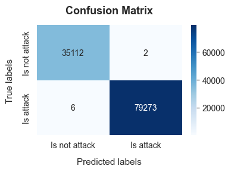

```python
plot_confusion_matrix(Y_test, xgboost["y_proba"] >= xgboost["metrics"][xgboost["metrics"]["RecallScore"] >= 0.99].sort_values("F1Score", ascending=False)["Threshold"].iloc[0])
```

## LightGBM

LightGBM is a high-performance gradient boosting framework built on decision tree algorithms. It is widely used for ranking, classification, and many other machine learning tasks. Works particularly well with large datasets and a large number of independent variables, optimizing heavily for speed and memory efficiency. LightGBM grows trees leaf-wise, evaluates all leaves and expands the single leaf that reduces the loss the most. It uses histogram-based algorithms to group continuous feature values into discrete bins. This drastically reduces memory usage and speeds up training. It can handle categorical features directly without requiring to manually apply encoding first. Because leaf-wise growth is quite aggressive, LightGBM can easily overfit, especially on smaller datasets. To prevent this, careful tuning of hyperparameters like max_depth, num_leaves, and min_data_in_leaf is strictly required.

```python
def run_light_gbm():
    scale_pos_weight = len(Y_train[Y_train.eq(0)]) / len(Y_train[Y_train.eq(1)])

    parameters = {
        "n_estimators": [200, 300, 400],
        "max_depth": [-1], # -1 = sem restrições  -  para fins de inspeção, em caso de suspeita de overfitting, aumentar para 5 para limitar
        "num_leaves": [31, 63, 127],# para fins de inspeção, em caso de suspeita de overfitting, reduzir para 15
        "learning_rate": [0.01, 0.02, 0.05],
        "subsample": [0.7, 0.8, 0.9],
        "colsample_bytree": [0.7, 0.8, 0.9],
        "scale_pos_weight": [scale_pos_weight*0.5, scale_pos_weight, scale_pos_weight*1.5]
    }

    lgbm = LGBMClassifier( random_state=42, n_jobs=-1 )

    cv = RandomizedSearchCV(
        estimator=lgbm,
        param_distributions=parameters,
        n_iter=20,
        scoring={"recall": "recall", "f1": "f1", "precision": "precision"},
        refit="f1",
        cv=StratifiedKFold(n_splits=3, shuffle=True, random_state=42),
        verbose=1,
        random_state=42,
        n_jobs=-1
    )

    cv.fit(X_train, Y_train)

    best_model = cv.best_estimator_

    proba = best_model.predict_proba(X_test)[:, 1]

    results = []
    for t in np.linspace(0.0, 1.0, 101):
        y_pred = (proba >= t)
        cm = confusion_matrix(Y_test, y_pred)
        results.append({
            "Threshold": t,
            "PrecisionScore": precision_score(Y_test, y_pred, zero_division=0),
            "RecallScore": recall_score(Y_test, y_pred, zero_division=0),
            "F1Score": f1_score(Y_test, y_pred, zero_division=0),
            "TP": cm[1, 1],
            "TN": cm[0, 0],
            "FP": cm[0, 1],
            "FN": cm[1, 0],
            "MCC": matthews_corrcoef(Y_test, y_pred)
        })

    df_metrics = pd.DataFrame(results)
    df_metrics.to_csv("light_gbm_metrics.csv", index=False)
    df_cv_results = pd.DataFrame(cv.cv_results_)
    df_cv_results.to_csv("light_gbm_cv_results.csv", index=False)

    df_importances = pd.DataFrame({
        "Feature": X.columns,
        "Importance": best_model.booster_.feature_importance(importance_type="gain")
    })
    df_importances = df_importances.sort_values("Importance", ascending=False).round().reset_index(drop=True).transpose()

    return { "metrics": df_metrics, "best_params": cv.best_params_, "best_model": best_model, "importances": df_importances, "cv_results": df_cv_results, "y_pred": y_pred, "y_proba": proba }

light_gbm = run_light_gbm()
models.update({"LightGBM": light_gbm})
```

```python
light_gbm["metrics"].iloc[50:55]
```

|  | Threshold | PrecisionScore | RecallScore | F1Score | TP | TN | FP | FN | MCC |
| --- | --- | --- | --- | --- | --- | --- | --- | --- | --- |
| 50 | 0.50 | 0.99995 | 0.999950 | 0.999950 | 79275 | 35110 | 4 | 4 | 0.999836 |
| 51 | 0.51 | 0.99995 | 0.999950 | 0.999950 | 79275 | 35110 | 4 | 4 | 0.999836 |
| 52 | 0.52 | 0.99995 | 0.999937 | 0.999943 | 79274 | 35110 | 4 | 5 | 0.999815 |
| 53 | 0.53 | 0.99995 | 0.999937 | 0.999943 | 79274 | 35110 | 4 | 5 | 0.999815 |
| 54 | 0.54 | 0.99995 | 0.999937 | 0.999943 | 79274 | 35110 | 4 | 5 | 0.999815 |

The following table shows the computed feature importance from highest to lowest.

```python
light_gbm["importances"]
```

|  | 0 | 1 | 2 | 3 | 4 | 5 | 6 | 7 | 8 |
| --- | --- | --- | --- | --- | --- | --- | --- | --- | --- |
| Feature | Flow Bytes/s | Init_Win_bytes_backward | Subflow Fwd Bytes | Packet Length Std | Init_Win_bytes_forward | Flow Packets/s | Subflow Fwd Packets | Down/Up Ratio | Flow Duration |
| Importance | 698680.0 | 510218.0 | 501723.0 | 182248.0 | 41158.0 | 5448.0 | 4223.0 | 3728.0 | 1305.0 |

A confusion matrix is shown below for a minimum probability equal to the threshold corresponding to the maximum F1Score for a RecallScore equal or higher than 0.99.

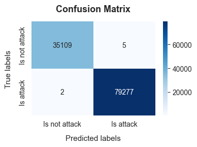

```python
plot_confusion_matrix(Y_test, light_gbm["y_proba"] >= light_gbm["metrics"][light_gbm["metrics"]["RecallScore"] >= 0.99].sort_values("F1Score", ascending=False)["Threshold"].iloc[0])
```

## CatBoost

CatBoost is a high-performance gradient boosting framework built on decision tree algorithms. It is widely used for classification, regression, and ranking tasks, particularly on tabular data. CatBoost introduces ordered boosting, a technique designed to reduce overfitting by preventing information leakage during training. It also uses symmetric trees, where the same splitting condition is applied across each level, improving prediction speed and model stability. One of its main advantages is the ability to handle categorical features directly without requiring extensive preprocessing. CatBoost is generally robust to hyperparameter choices and requires less tuning compared to other gradient boosting frameworks. However, it can be slower to train than LightGBM, especially on very large datasets.

Although CatBoost provides a large number of configurable hyperparameters, it typically requires less manual tuning than frameworks such as LightGBM or XGBoost, due to its robust default settings and built-in mechanisms for handling categorical features and reducing overfitting.

```python
def run_cat_boost():

    parameters = {
        "class_weights": [{0:1, 1:w} for w in range(1, 16)],
        "iterations": [300],
        "depth": [4, 6, 8],
        "learning_rate": [0.02, 0.05, 0.1],
        "loss_function": ['Logloss'],
        "eval_metric": ["F1"],
        "verbose": [0]
    }

    catboost = CatBoostClassifier( random_state=42, thread_count=-1 )

    cv = RandomizedSearchCV(
        estimator=catboost,
        param_distributions=parameters,
        n_iter=10,
        scoring={"recall": "recall", "f1": "f1", "precision": "precision"},
        refit="f1",
        cv=StratifiedKFold(n_splits=3, shuffle=True, random_state=42),
        verbose=1,
        random_state=42
    )

    cv.fit(X_train, Y_train)

    best_model = cv.best_estimator_

    proba = best_model.predict_proba(X_test)[:, 1]

    results = []
    for t in np.linspace(0.0, 1.0, 101):
        y_pred = (proba >= t)
        cm = confusion_matrix(Y_test, y_pred)
        results.append({
            "Threshold": t,
            "PrecisionScore": precision_score(Y_test, y_pred, zero_division=0),
            "RecallScore": recall_score(Y_test, y_pred, zero_division=0),
            "F1Score": f1_score(Y_test, y_pred, zero_division=0),
            "TP": cm[1, 1],
            "TN": cm[0, 0],
            "FP": cm[0, 1],
            "FN": cm[1, 0],
            "MCC": matthews_corrcoef(Y_test, y_pred)
        })

    df_metrics = pd.DataFrame(results)
    df_metrics.to_csv("cat_boost_metrics.csv", index=False)
    df_cv_results = pd.DataFrame(cv.cv_results_)
    df_cv_results.to_csv("cat_boost_cv_results.csv", index=False)

    df_importances = pd.DataFrame({
        "Feature": X.columns,
        "Importance": best_model.get_feature_importance()
    })
    df_importances = df_importances.sort_values("Importance", ascending=False).round().reset_index(drop=True).transpose()

    return { "metrics": df_metrics, "best_params": cv.best_params_, "best_model": best_model, "importances": df_importances, "cv_results": df_cv_results, "y_pred": y_pred, "y_proba": proba }

cat_boost = run_cat_boost()
models.update({"CatBoost": cat_boost})
```

```python
cat_boost["metrics"].iloc[50:55]
```

|  | Threshold | PrecisionScore | RecallScore | F1Score | TP | TN | FP | FN | MCC |
| --- | --- | --- | --- | --- | --- | --- | --- | --- | --- |
| 50 | 0.50 | 0.999937 | 0.999937 | 0.999937 | 79274 | 35109 | 5 | 5 | 0.999795 |
| 51 | 0.51 | 0.999937 | 0.999937 | 0.999937 | 79274 | 35109 | 5 | 5 | 0.999795 |
| 52 | 0.52 | 0.999950 | 0.999937 | 0.999943 | 79274 | 35110 | 4 | 5 | 0.999815 |
| 53 | 0.53 | 0.999950 | 0.999937 | 0.999943 | 79274 | 35110 | 4 | 5 | 0.999815 |
| 54 | 0.54 | 0.999950 | 0.999937 | 0.999943 | 79274 | 35110 | 4 | 5 | 0.999815 |

The following table shows the computed feature importance from highest to lowest.

```python
cat_boost["importances"]
```

|  | 0 | 1 | 2 | 3 | 4 | 5 | 6 | 7 | 8 |
| --- | --- | --- | --- | --- | --- | --- | --- | --- | --- |
| Feature | Subflow Fwd Bytes | Init_Win_bytes_backward | Packet Length Std | Init_Win_bytes_forward | Down/Up Ratio | Flow Bytes/s | Flow Duration | Flow Packets/s | Subflow Fwd Packets |
| Importance | 35.0 | 25.0 | 13.0 | 9.0 | 6.0 | 5.0 | 3.0 | 3.0 | 2.0 |

A confusion matrix is shown below for a minimum probability equal to the threshold corresponding to the maximum F1Score for a RecallScore equal or higher than 0.99.

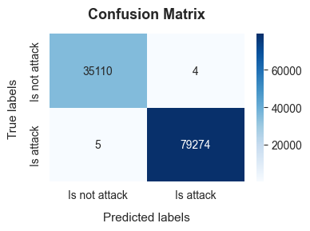

```python
plot_confusion_matrix(Y_test, cat_boost["y_proba"] >= cat_boost["metrics"][cat_boost["metrics"]["RecallScore"] >= 0.99].sort_values("F1Score", ascending=False)["Threshold"].iloc[0] )
```

# Model Comparison and Selection

The next step is to define the desired model outcome. If minimizing false positives is the priority in malicious traffic detection, then configurations with higher precision should be preferred. However, this comes at the cost of increased false negatives, meaning that more malicious traffic may go undetected.

Model selection is performed by first enforcing a minimum Recall of 0.99, ensuring that a sufficient proportion of malicious traffic is detected. Among the models satisfying this constraint, the one with the best metrics overall and calibration curve is selected, as it provides the best balance between precision and recall. This approach aligns model performance with the business requirements of maximizing malicious traffic detection while controlling the number of false positives. This selection process reflects a practical decision framework, where recall acts as a hard requirement and the remaining metrics are used for performance optimization within that constraint.

```python
def model_comparison():
    df_all = []

    for name, model in models.items():
        df = model["metrics"].copy()
        df["Model"] = name
        cols = ["Threshold", "PrecisionScore", "RecallScore", "F1Score", "TP", "TN", "FP", "FN", "MCC"]
        df = df[["Model"] + [c for c in cols if c in df.columns]]
        logloss = log_loss(Y_test, model["y_proba"])
        brier = brier_score_loss(Y_test, model["y_proba"])
        roc = roc_auc_score(Y_test, model["y_proba"])
        pr = average_precision_score(Y_test, model["y_proba"])
        df["LogLoss"] = logloss
        df["BrierScoreLoss"] = brier
        df["ROC_AUC"] = roc
        df["PR_AUC"] = pr
        df_all.append(df)

    df_all = pd.concat(df_all).reset_index(drop=True)

    models_best_performance = df_all[df_all["RecallScore"] >= 0.99].sort_values(["F1Score"], ascending=[False]).drop_duplicates("Model").reset_index(drop=True)

    return { "models_best_performance": models_best_performance, "comparison_across_threshold": df_all }

df_comparison = model_comparison()
```

```python
df_comparison["models_best_performance"]
```

|  | Model | Threshold | PrecisionScore | RecallScore | F1Score | TP | TN | FP | FN | MCC | LogLoss | BrierScoreLoss | ROC_AUC | PR_AUC |
| --- | --- | --- | --- | --- | --- | --- | --- | --- | --- | --- | --- | --- | --- | --- |
| 0 | LightGBM | 0.28 | 0.999937 | 0.999975 | 0.999956 | 79277 | 35109 | 5 | 2 | 0.999856 | 0.000623 | 0.000067 | 0.999985 | 0.999995 |
| 1 | XGBoost | 0.79 | 0.999975 | 0.999924 | 0.999950 | 79273 | 35112 | 2 | 6 | 0.999836 | 0.000469 | 0.000074 | 0.999988 | 0.999996 |
| 2 | CatBoost | 0.52 | 0.999950 | 0.999937 | 0.999943 | 79274 | 35110 | 4 | 5 | 0.999815 | 0.000526 | 0.000074 | 0.999989 | 0.999996 |
| 3 | Random Forest | 0.38 | 0.999962 | 0.999886 | 0.999924 | 79270 | 35111 | 3 | 9 | 0.999753 | 0.000984 | 0.000137 | 0.999983 | 0.999994 |
| 4 | Logistic Regression | 0.69 | 0.989481 | 0.991927 | 0.990703 | 78639 | 34278 | 836 | 640 | 0.969635 | 0.170828 | 0.047918 | 0.991434 | 0.994889 |

Based on the model comparison results, LightGBM, XGBoost, CatBoost, and Random Forest exhibit very similar performance, with only marginal differences across evaluation metrics.

All four tree-based models achieve near-perfect recall and precision, indicating that the dataset is highly separable using the selected flow-based features. LightGBM achieves slightly higher recall and F1-score at a tuned decision threshold while maintaining a very low number of false positives, which is desirable in intrusion detection systems where missed malicious traffic is costly.

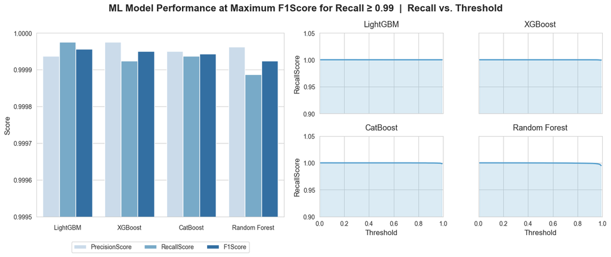

```python
def plot_model_comparison():

    fig = plt.figure(figsize=(14, 6))
    fig.suptitle( "ML Model Performance at Maximum F1Score for Recall ≥ 0.99  |  Recall vs. Threshold", y=0.98, fontsize=16, fontweight="bold" )
    gs = gridspec.GridSpec(2, 3, width_ratios=[2, 1, 1])

    df_comparison_filtered = df_comparison["comparison_across_threshold"][df_comparison["comparison_across_threshold"]["Model"].isin(list(df_comparison["models_best_performance"]["Model"].head(4)))]
    data = df_comparison_filtered[~df_comparison_filtered["Threshold"].isin([0.0, 1.0])]

    df_melt = df_comparison["models_best_performance"].head(4).melt(
        id_vars="Model",
        value_vars=["PrecisionScore", "RecallScore", "F1Score"]
    )

    ax_main = fig.add_subplot(gs[:, 0])

    sns.barplot(
        data=df_melt,
        x="Model",
        y="value",
        hue="variable",
        ax=ax_main,
        palette="Blues" # "Blues", "Reds", "Oranges", "Greens", "Purples", "Greys", "Blues", "deep", "muted", "dark", "colorblind",
    )

    ax_main.set_ylabel("Score", fontsize=12)
    ax_main.set_ylim(0.9995, 1)
    ax_main.set_xlabel("")
    ax_main.tick_params(axis='x', rotation=0, pad=10)
    ax_main.legend(loc="upper center", bbox_to_anchor=(0.5, -0.12), ncol=df_melt["variable"].nunique())

    ax1 = fig.add_subplot(gs[0, 1])
    ax2 = fig.add_subplot(gs[0, 2], sharey=ax1)
    ax3 = fig.add_subplot(gs[1, 1], sharex=ax1)
    ax4 = fig.add_subplot(gs[1, 2], sharex=ax2, sharey=ax3)
    axes_right = [ax1, ax2, ax3, ax4]

    for ax in [ax1, ax2]:
        ax.tick_params(labelbottom=False)
    for ax in [ax2, ax4]:
        ax.tick_params(labelleft=False)

    models = df_comparison["models_best_performance"]["Model"].head(4)

    for ax, model in zip(axes_right, models):

        data_model = data[data["Model"] == model]
        df_long = data_model.melt(
            id_vars="Threshold",
            value_vars=["RecallScore"],
            var_name="Metric",
            value_name="Score"
        )

        palette = sns.color_palette("Blues")
        sns.lineplot(
            data=df_long,
            x="Threshold",
            y="Score",
            ax=ax,
            color=palette[3],
            linewidth=2
        )

        ax.set_title(model, fontsize=13, pad=10)
        ax.fill_between( df_long["Threshold"], df_long["Score"], color=palette[2], alpha=0.3 )
        ax.set_ylim(0.9, 1.05)
        ax.set_xlim(0, 1)
        ax.set_xlabel("Threshold", fontsize=12)
        ax.set_ylabel("RecallScore", fontsize=12)

    plt.tight_layout()
    plt.show()

plot_model_comparison()
```

Overall, the extremely high performance across all models indicates that the dataset exhibits strong intrinsic separability, rather than the superiority of a specific algorithm.

In the context of network intrusion detection, recall is the most critical metric, as failing to detect malicious traffic has severe consequences. Precision remains important to limit false positives and maintain system usability. Given these considerations, and its slightly superior recall performance under threshold tuning, LightGBM is selected as the final model.

It is important to note that the dataset presents moderate class imbalance (aprox. 69% malicious traffic), and the near-perfect evaluation metrics suggest that results may be influenced by the structured nature of the dataset.

The ROC curves below for the top four models are nearly identical and exhibit a near-square shape, indicating extremely high class separability and similar ranking performance. This suggests that model choice has minimal impact, as the underlying feature space already allows for near-perfect discrimination between classes. Differences in classification metrics are therefore negligible and within expected variance.

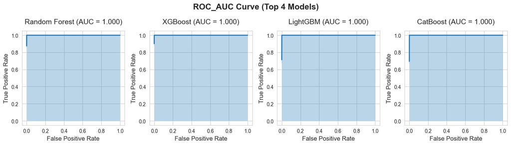

```python
def model_roc_curve():

    valid_models = set(df_comparison["models_best_performance"]["Model"].head(4))
    filtered_models = {k: v for k, v in models.items() if k in valid_models}
    fig, axes = plt.subplots(1, 4, figsize=(14, 4))

    for i, (name, model) in enumerate(filtered_models.items()):
        fpr, tpr, _ = roc_curve(Y_test, model["y_proba"])
        auc = roc_auc_score(Y_test, model["y_proba"])
        df = pd.DataFrame({"false_positive_rate": fpr, "true_positive_rate": tpr})
        sns.lineplot(
            data=df,
            x="false_positive_rate",
            y="true_positive_rate",
            ax=axes[i],
            linewidth=2
            #label=name
        )
        axes[i].fill_between( df["false_positive_rate"], df["true_positive_rate"], alpha=0.3 )
        axes[i].set_title(f"{name} (AUC = {auc:.3f})", fontsize=14, pad=14)
        axes[i].set_xlabel("False Positive Rate", fontsize=12)
        axes[i].set_ylabel("True Positive Rate", fontsize=12)

    plt.suptitle("ROC_AUC Curve (Top 4 Models)", y=0.98, fontsize=16, fontweight="bold")
    plt.tight_layout()
    plt.show()

model_roc_curve()
```

The calibration curves below for the top-performing models exhibit irregular shapes, particularly in the mid-probability range, with most predicted probabilities concentrated near 0 or 1. This suggests that the models tend to produce highly confident predictions, which may indicate strong class separability in feature space or model overconfidence resulting from overfitting, leading to near-deterministic probability outputs rather than well-calibrated probabilistic estimates.

This behavior could potentially be influenced by the presence of more than 160,000 duplicated rows in the dataset, which correspond to repeated network traffic flows exhibiting identical values across the selected feature set. These duplicates are not artifacts of data fabrication, but rather reflect recurring observations of the same traffic patterns. However, a second experiment in which duplicated rows were removed yielded similar “near-perfect” performance metrics and an even more binary calibration curve, suggesting that data duplication alone does not fully explain the observed overconfidence.

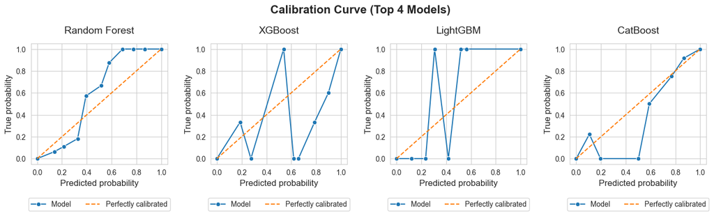

```python
def model_calibration_curve():

    valid_models = set(df_comparison["models_best_performance"]["Model"].head(4))
    filtered_models = {k: v for k, v in models.items() if k in valid_models}
    fig, axes = plt.subplots(1, 4, figsize=(14, 4.5))

    for i, (name, model) in enumerate(filtered_models.items()):
        bins = 11
        prob_true, prob_pred = calibration_curve(Y_test, model["y_proba"], n_bins=bins)
        df = pd.DataFrame({"prob_true": prob_true, "prob_pred": prob_pred})

        # modelo
        sns.lineplot(
            data=df,
            x="prob_pred",
            y="prob_true",
            ax=axes[i],
            marker='o',
            label="Model"
        )

        # Perfeitamente calibrada
        sns.lineplot(
            x=[0, 1],
            y=[0, 1],
            ax=axes[i],
            linestyle='--',
            label="Perfectly calibrated"
        )

        axes[i].set_title(f"{name}", fontsize=14, pad=14)
        axes[i].set_xlabel("Predicted probability", fontsize=12)
        axes[i].set_ylabel("True probability", fontsize=12)
        axes[i].legend(loc="upper center", bbox_to_anchor=(0.5, -0.25), ncol=4)

    plt.suptitle("Calibration Curve (Top 4 Models)", y=0.98, fontsize=16, fontweight="bold")
    plt.tight_layout()
    plt.show()

model_calibration_curve()
```

An inspection also confirmed that there are no overlapping rows in the dataset. After ruling out several potential sources of data leakage, an additional experiment was conducted to evaluate whether model capacity was contributing to the observed performance. The capacity of the best-performing model, LightGBM, was reduced by decreasing max_depth to 5 and num_leaves to 15. Despite this constraint, the model achieved nearly identical performance, suggesting that high model complexity is not the primary driver of the results. Instead, the results may be driven by the high separability of classes in this dataset.

The SHAP summary plot below indicates that malicious traffic detection is driven by several key features. Subflow Fwd Bytes is among the features with the strongest influence, with a portion of higher values strongly associated with a decreased probability of malicious traffic, while lower exhibit a less consistent effect. Higher values of Packet Length Std and Init_Win_bytes_forward are also strongly associated with an increased likelihood of malicious traffic. In contrast, higher values of Init_Win_bytes_backward and Down/Up Ratio contribute to a decreased probability of malicious traffic classification.

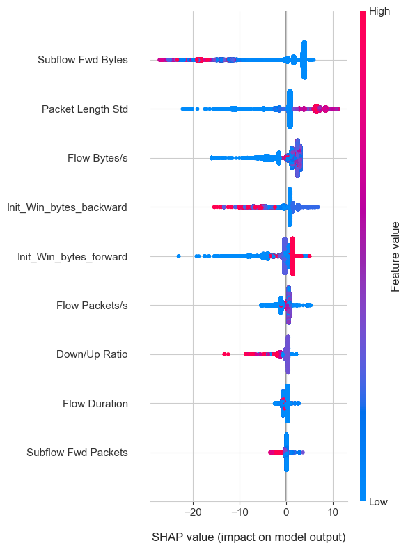

```python
def features_impact(model):
    warnings.filterwarnings("ignore", message="LightGBM binary classifier with TreeExplainer shap values output has changed")
    explainer = shap.TreeExplainer(model)
    shap_values = explainer.shap_values(X_test)
    return shap_values

def plot_summary_plot(model):
    shap_values = features_impact(model)
    shap.summary_plot(shap_values, X_test, plot_size=(6, 8), show=False)
    ax = plt.gca()
    ax.tick_params(axis='y', labelsize=11)
    ax.tick_params(axis='x', labelsize=11)
    plt.xlabel("SHAP value (impact on model output)", fontsize=12, labelpad=15)
    plt.tight_layout()
    plt.show()

plot_summary_plot(models[df_comparison["models_best_performance"]["Model"].iloc[0]]['best_model'])
```

The SHAP dependence plot illustrates how Subflow Fwd Bytes influences model predictions, with values colored by Packet Length Std, the feature with the strongest interaction. The SHAP values are predominantly negative, mostly below 5, indicating that higher values of Subflow Fwd Bytes generally push predictions toward the normal traffic class. At low values of Subflow Fwd Bytes, the contribution is more variable, reflecting greater model uncertainty. As the feature value increases, the SHAP values stabilize in the negative range. The interaction with Packet Length Std primarily affects the magnitude of this contribution: higher values of Packet Length Std tend to amplify the negative impact, while lower values are associated with more dispersed effects.

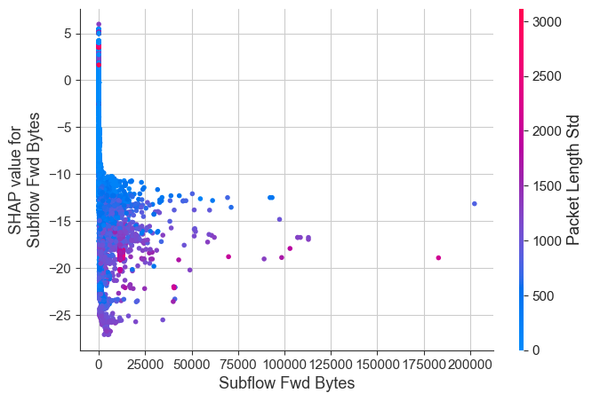

```python
shap.dependence_plot("Subflow Fwd Bytes", features_impact(models[df_comparison["models_best_performance"]["Model"].iloc[0]]['best_model']), X_test)
```

# Final Evaluation and Conclusion

Feature selection analysis, combined with correlation analysis, indicates that a reduced subset of variables captures most of the predictive signal, while several features are redundant, contribute negligibly, or introduce noise that can degrade model performance. The dataset contains features that provide a strong and clear signal for distinguishing malicious traffic from normal traffic, resulting in near-perfect class separation across multiple models. This suggests that the high performance observed is driven not only by model capability, but also by the strong intrinsic separability of the dataset in the selected feature space.